# Data Science Final: Exploring the geospatial distribution and accessibility of water points across Rohingya refugee camps in Bangladesh

Author

Serenity Fan, Cristina Pirela, Santiago Rodriguez, Young-Ju Man

# Background and Literature Review

The effects of the genocide of the Rohingya Muslim people by the Myanmar military, as exemplified by the mass exodus displacement of 700,000 Rohingya in 2017 from Myanmar’s Rakhine state, persist to this day. Many Rohingya continue to live in refugee camps in adjacent Cox’s Bazar, Bangladesh, in extremely crowded and unsanitary conditions. In humanitarian contexts, a household’s distance to the nearest clean/improved water source greatly affects daily life, with respect to time spent collecting water, nutrition, health (incidence of water-borne diseases such as cholera, diarrhea, etc.), female agency/power in the household, and the incidence of gender-based violence (e.g. women/girls fetching water in poorly-lit areas).

Our motivating question is to understand access to water facilities in refugee camps in Cox’s Bazar, and to verify and assess the extent to which those facilities are satisfying UNHCR guidelines. To do so, we will explore the geospatial distribution of water points across Rohingya refugee camps in Bangladesh. This has implications for the targeting and provision of water and sanitation services in humanitarian response.

## Data Sources:

### Water Point Data Exchange (WPDX):

Global repository of water points, including geographic coordinates. The database can be filtered by country, and our team has verified that it contains extensive data for Bangladesh: over 70,000 observations. The following code chunk uses an API call to download water point data for Bangladesh.

```r
#Downloading the WPDX
df <- read.socrata(
  "https://data.waterpointdata.org/resource/eqje-vguj.json?country_id=BGD",
  app_token = "PjQJU7Ifj1RWCnOXDj8EZtswc",
  email     = "kaf121@georgetown.edu",
  password  = "El3vator!"
)
```

### Administrative division data

The following code chunk loads Subnational Administrative Boundaries for Bangladesh. The data comes from the Bangladesh Data Grid, maintained by The Humanitarian Data Exchange (HDX). The HDX is a USAID-funded and OCHE-run open data platform designed to facilitate sharing of data relevant to development and humanitarian contexts. The specified dataset is available [here](https://data.humdata.org/dataset/401d3fae-4262-48c9-891f-461fd776d49b/resource/08736818-ae72-44a9-abd6-a51915c24921/download/bgd_adm_bbs_20201113_shp.zip), and must be downloaded prior to running the code. To ensure the code runs correctly, use the bgd_admbnda_adm4_bbs_20201113.shp file from the download folder.

```r
# Load the districts shapefile}

districts <- st_read("bgd_adm_bbs_20201113_SHP/bgd_admbnda_adm4_bbs_20201113.shp")
```

### Downloading refuge camp data

The following code chunk loads and plots geographical boundaries for refugee camps in Cox’s Bazar. The data also comes from the Bangladesh Data Grid maintained by HDX.The specified dataset is available [here](https://data.humdata.org/dataset/outline-of-camps-sites-of-rohingya-refugees-in-cox-s-bazar-bangladesh?), and must be downloaded prior to running the code. The data is available at the camp level, the camp block level, and the camp sub-block level. To ensure the code runs correctly, use the 20230412_Camp Boundaries_A1, A2, A3.gdb file from the download folder.

```r
camp_data <- st_read("20230412_Camp Boundaries_A1, A2, A3.gdb")
```

```
Multiple layers are present in data source C:\Users\kevin\Github\Data-Science-Final-Project\20230412_Camp Boundaries_A1, A2, A3.gdb, reading layer `T20230412_A3_Camp_SubBlock_Outlines'.
Use `st_layers' to list all layer names and their type in a data source.
Set the `layer' argument in `st_read' to read a particular layer.
```

```r
camp_layers <- st_layers(dsn = "20230412_Camp Boundaries_A1, A2, A3.gdb")

camp_outlines <- st_read("20230412_Camp Boundaries_A1, A2, A3.gdb", "T20230412_A1_Camp_Outlines")
camp_block_outlines <- st_read("20230412_Camp Boundaries_A1, A2, A3.gdb", "T20230412_A2_Camp_Block_Outlines")
camp_sub_block_outlines <- st_read("20230412_Camp Boundaries_A1, A2, A3.gdb", "T20230412_A3_Camp_SubBlock_Outlines")
```

### UNHCR Population Factsheet

Joint Government of Bangladesh - Block Level as of November 2023.

Please download the population data from below link first [here] (https://data.unhcr.org/en/documents/details/105303)

```r
# Read only necessary columns in the Excel file to merge population data matching with Block SSID column

refugee_data <- read_excel("UNHCR Population Factsheet  Block Level Data - November 2023.xlsx", range = "A6:H1000")
```

### Latrine, Bathing Cubicle and Tubewell Location Map and Dataset - May 2023

The following code chunk loads geographical points for Tubewells/Latrines/Bathing Cubicles for refugee camps in Cox’s Bazar. The data comes from the Rohingya Refugee Response maintained by UNICEF.The specified dataset is available [here](https://drive.google.com/drive/folders/1wJR0QBXhE_PwWJDI-pDM3jcdjjB1S7zc), and must be downloaded prior to running the code. The data can be filtered by District, Camp Name, and Type of Beneficiaries.

```r
tubewells <- read_excel("WASH_Infrastructures_GPS dataset_(LT_TW_Bath)_May_01_2023.xlsx", sheet = 3) %>%
  filter(`Type of Beneficiaries` == "Rohingya")
```

### Health Facility Data

On January 2018, partners from the Cox Bazar Health Sector conducted a mapping exercise of the Health Facilities in the refugee camp areas. Due to the highly dynamic nature of the situation, new health facilities are still being constructed and others removed. It is therefore important to note that this may not be comprehensive or truly representative of infrastructure at the time of publication. Also note that the spatial accuracy of this dataset is at best just under 5m, which can influence the analysis of infrastructure coverage.

Link [here](https://data.humdata.org/dataset/cox-s-bazar-refugee-settlement-health-facilities/resource/9aa4e102-73cb-4b77-be2d-c9560d6ee9db) Data Sources: Cox Bazar Health Sector/WHO

```r
health_facilities <- read_excel("cox_bazar_health_sector_infrastructure_january_2018.xlsx", sheet = 2)
```

## WPDX Cleaning

The data is filtered to only include water points in Cox’s Bazar, and is later mapped and classified according to the water point’s status (Functional, Non-functional, and Non-functional during the dry season).

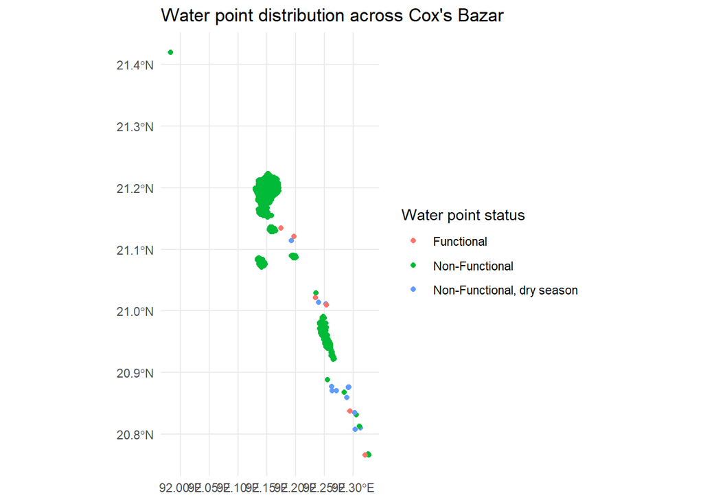

```r
#Filtering the data
filtered_df <- df %>%
  filter(!is.na(lat_deg), !is.na(lon_deg)) %>%
  filter(clean_adm2 == "Cox'S Bazar")

filtered_df <- st_as_sf(filtered_df, coords = c("lon_deg", "lat_deg"), remove = FALSE) %>%
  st_set_crs(value = 4326)

#Ploting the map:
ggplot() +
  geom_sf(data = filtered_df, aes(color = status_clean)) +
  labs(
    color = "Water point status",
    title = "Water point distribution across Cox's Bazar") +
  theme_minimal()
```

## Administrative division data

The following code chunk filters and plots Subnational Administrative Boundaries for Bangladesh.

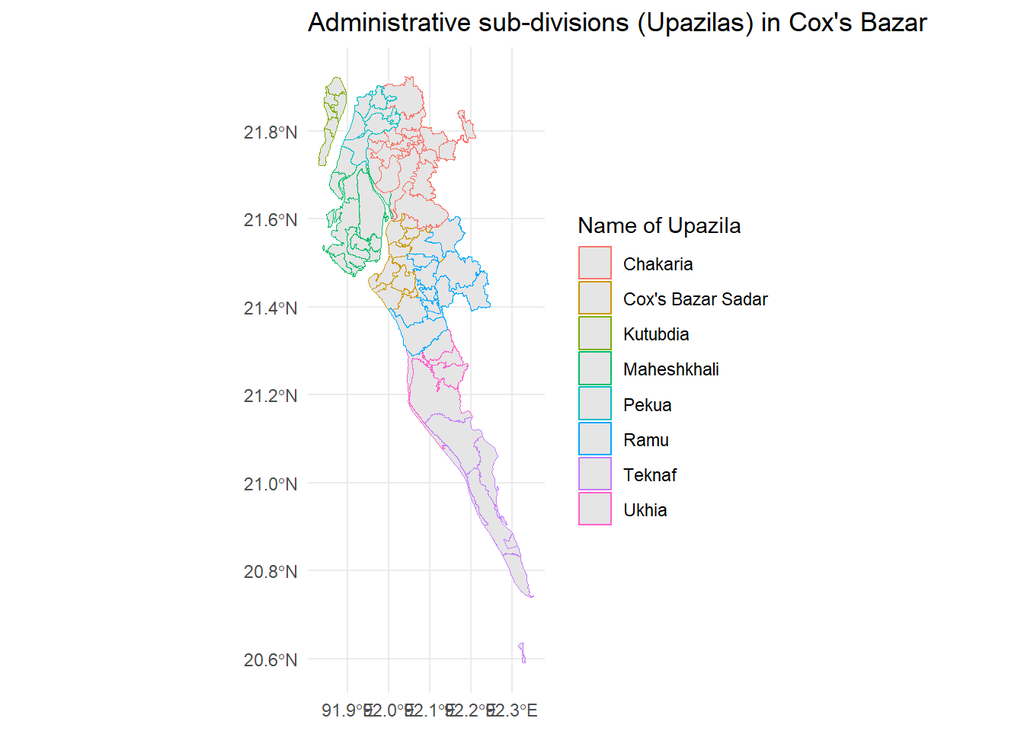

```r
# Filter the data
filtered_districts <- districts %>%
  filter(ADM2_EN == "Cox's Bazar")

#Plot the map:
ggplot() +
  geom_sf(data = filtered_districts, aes(color = ADM3_EN)) +
  labs(
    color = "Name of Upazila",
    title = "Administrative sub-divisions (Upazilas) in Cox's Bazar") +
  theme_minimal()
```

## Plotting Refuge Camp Data

The following code chunk plots geographical boundaries for refugee camps in Cox’s Bazar.

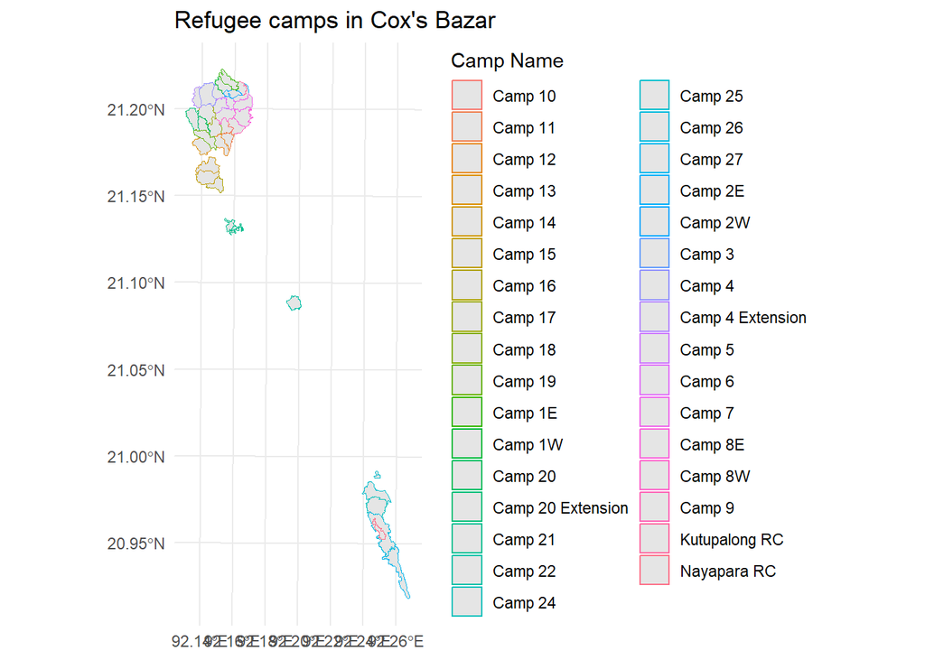

```r
#Plot the map:
ggplot() +
  geom_sf(data = camp_outlines, aes(color = CampName)) +
  labs(
    color = "Camp Name",
    title = "Refugee camps in Cox's Bazar") +
  theme_minimal()
```

## Focusing on specific camp regions (Ukhia and Teknaf)

The following code chunks are mapping specific two camp areas to make better visualizations. Furthermore, incorporating refugee population with density, it made easy to see which camp block has more densed refugee population

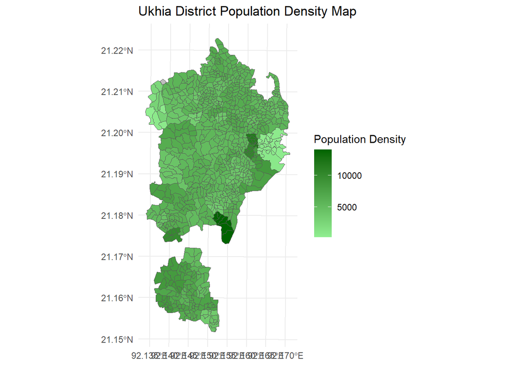

```r
# Merge population with existing camp district data based on 'Block SSID'
merged_data <- camp_data %>%
  left_join(refugee_data, by = c("BlockSSID" = "Block SSID"))

# Filter camp_data to include only Camp district
Ukhia_data <- merged_data[merged_data$CentroidY > 21.15, ]
Teknaf_data <- merged_data[merged_data$CentroidY < 21, ]
Ukhia_wp_data <- filtered_df[filtered_df$lat_deg > 21.15 & filtered_df$lat_deg < 21.23, ]
Teknaf_wp_data <- filtered_df[filtered_df$lat_deg < 21 & filtered_df$lat_deg > 20.90, ]

# Convert 'Total Individuals' to numeric for Ukhia
Ukhia_data$`Total Individuals` <- as.numeric(Ukhia_data$`Total Individuals`)

# Plotting for Ukhia
ggplot() +
  geom_sf(data = Ukhia_data, aes(fill = `Total Individuals`)) +
  scale_fill_gradient(low = "lightgreen", high = "darkgreen", na.value = "grey", name = "Population Density") +
  theme_minimal() +
  labs(title = "Ukhia District Population Density Map")
```

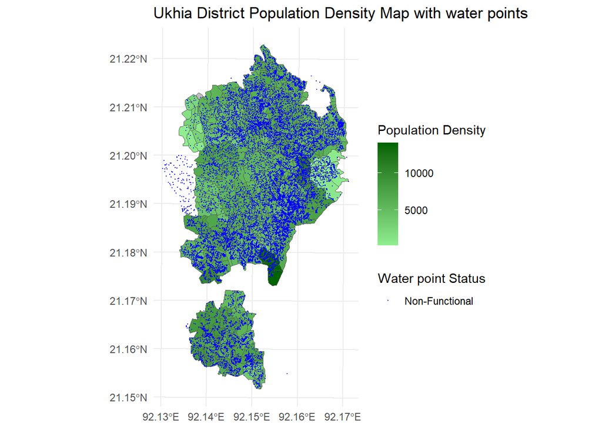

```r
# Plot the Ukhia Camp with Water point
ggplot() +
  geom_sf(data = Ukhia_data, aes(fill = `Total Individuals`)) +
  scale_fill_gradient(low = "lightgreen", high = "darkgreen", na.value = "grey", name = "Population Density") +
  theme_minimal() +

  geom_sf(data = Ukhia_wp_data, aes(color = status_clean), size = 0.1) +
  scale_color_manual(values = c("Functional" = "yellow", "Non-Functional, dry season" = "orange", "Non-Functional" = "blue")) +
  labs(fill = "CampName", color = "Water point Status") +
  labs(title = "Ukhia District Population Density Map with water points")
```

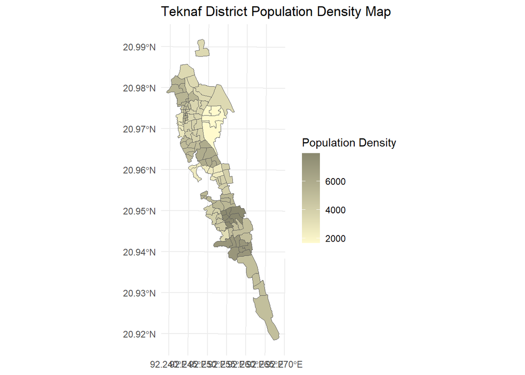

```r
# Convert 'Total Individuals' to numeric for Teknaf
Teknaf_data$`Total Individuals` <- as.numeric(Teknaf_data$`Total Individuals`)

# Plotting for Teknaf
ggplot() +
  geom_sf(data = Teknaf_data, aes(fill = `Total Individuals`)) +
  scale_fill_gradient(low = "lemonchiffon", high = "lemonchiffon4", na.value = "grey", name = "Population Density") +
  theme_minimal() +
  labs(title = "Teknaf District Population Density Map")
```

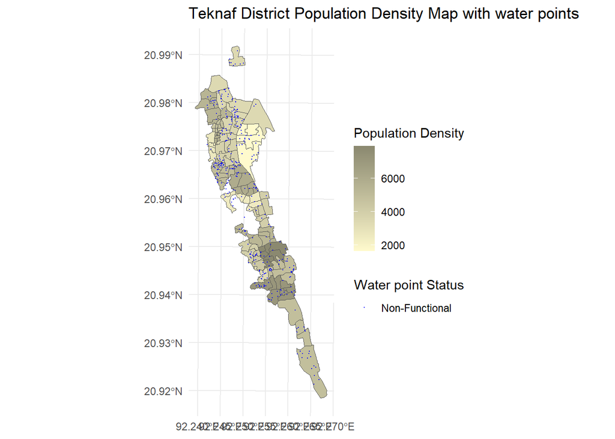

```r
# Plot the Teknaf Camp with Water point
ggplot() +
  geom_sf(data = Teknaf_data, aes(fill = `Total Individuals`)) +
  scale_fill_gradient(low = "lemonchiffon", high = "lemonchiffon4", na.value = "grey", name = "Population Density") +
  theme_minimal() +

  geom_sf(data = Teknaf_wp_data, aes(color = status_clean), size = 0.1) +
  scale_color_manual(values = c("Functional" = "green", "Non-Functional, dry season" = "orange", "Non-Functional" = "blue")) +
  labs(fill = "CampName", color = "Water point Status") +
  labs(title = "Teknaf District Population Density Map with water points")
```

## Combining the maps

The following code chunks combine previous visualizations, layering the water point data and refugee camp data over administrative divisions.

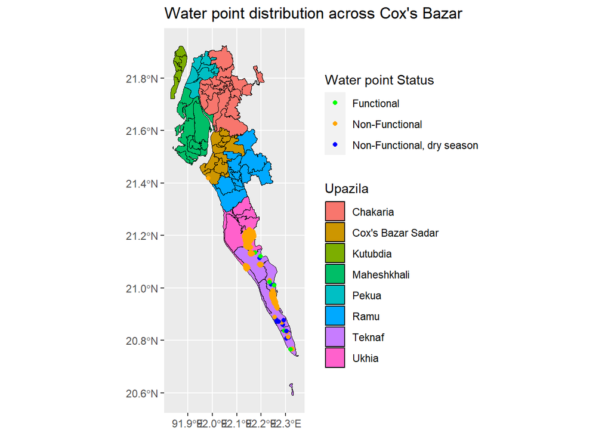

```r
# Combining the water point and district divisions maps
ggplot() +
  geom_sf(data = filtered_districts, aes(fill = ADM3_EN), color = "black") +
  scale_fill_discrete() +

  geom_sf(data = filtered_df, aes(color = status_clean)) +
  scale_color_manual(values = c("Functional" = "green", "Non-Functional, dry season" = "blue", "Non-Functional" = "orange")) +

  labs(fill = "Upazila", color = "Water point Status", title = "Water point distribution across Cox's Bazar")
```

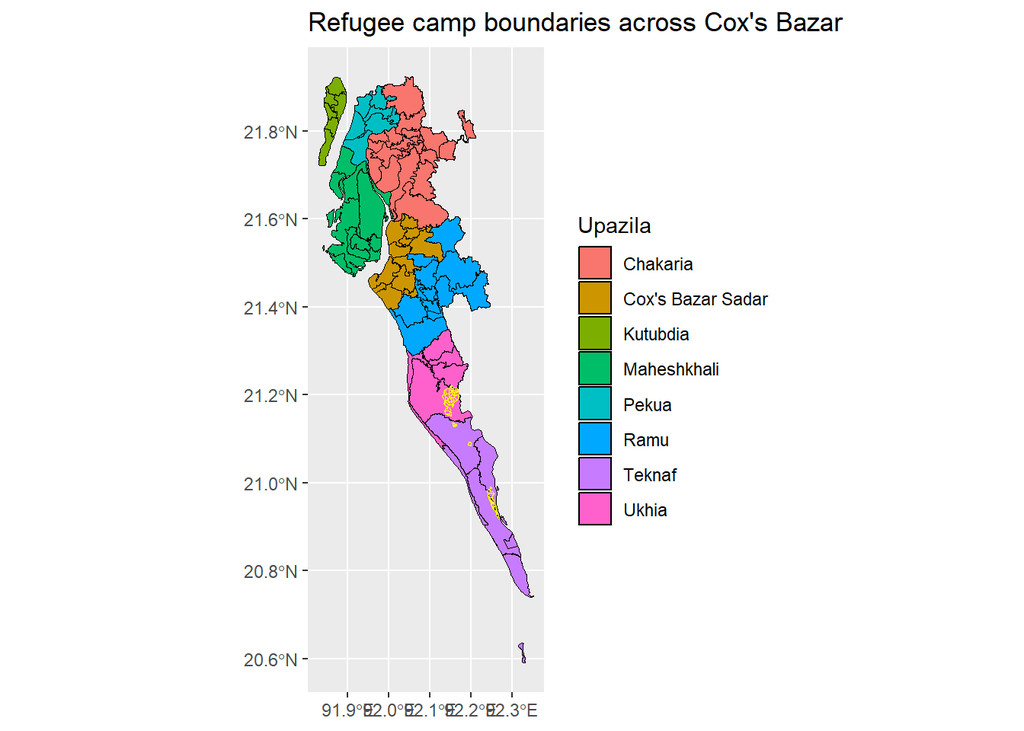

```r
# Combining the refuge camps and district maps
ggplot() +
  geom_sf(data = filtered_districts, aes(fill = ADM3_EN), color = "black") +
  geom_sf(data = camp_outlines, fill = "transparent", color = "yellow") +
  scale_fill_discrete(name = "Upazila") +
  scale_color_manual(name = "Refugee camp outlines", values = "yellow") +

  labs(title = "Refugee camp boundaries across Cox's Bazar")
```

## Function: maps for different districts

The following code chunk contains a function that generates layered maps for water point data, refugee camp boundaries and administrative divisions.

```r
plot_filtered_district <- function(district_filter, layer, water_point_filter, camp_outline_filter, Title, Level) {
  # Apply filters to the district and water point data
  new_filtered_districts <- dplyr::filter(filtered_districts, district_filter)
  new_filtered_df <- dplyr::filter(filtered_df, water_point_filter)
  new_filtered_camp_outlines <- dplyr::filter(camp_outlines, camp_outline_filter)

  # Plotting
  ggplot() +
    geom_sf(data = new_filtered_districts, aes(fill = !!as.name(layer)), color = "black") +
    geom_sf(data = new_filtered_df, aes(color = status_clean)) +
    scale_color_manual(values = c("Functional" = "green", "Non-Functional, dry season" = "blue", "Non-Functional" = "orange")) +
    geom_sf(data = new_filtered_camp_outlines, fill = "transparent", color = "yellow") +
    scale_fill_discrete(name = Level) +
    labs(
      color = "Water point Status",
      title = Title) +
    theme_minimal()
}
```

### Plots for different districts

The following code chunk uses the function described above to generate maps for the Ukhia and Teknaf Upazilas, since these administrative regions are the ones that contain both refugee camps and water points.

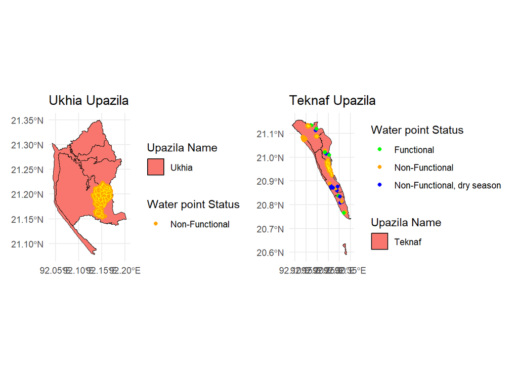

```r
Ukhia <- plot_filtered_district(district_filter = filtered_districts$ADM3_EN == "Ukhia",
                                layer = "ADM3_EN",
                                water_point_filter = filtered_df$clean_adm3 == "Ukhia",
                                camp_outline_filter = camp_outlines$Upazila == "Ukhia",
                                "Ukhia Upazila",
                                "Upazila Name")


Teknarf <- plot_filtered_district(district_filter = filtered_districts$ADM3_EN == "Teknaf",
                                  layer = "ADM3_EN",
                                  water_point_filter = filtered_df$clean_adm3 == "Teknaf",
                                  camp_outline_filter = camp_outlines$Upazila == "Teknaf",
                                  "Teknaf Upazila",
                                  "Upazila Name")
Ukhia + Teknarf
```

### Plots for different districts including sub district breakdown

The following code chunk uses the same function as above but changes the layer argument to display further administrative sub-divisions.

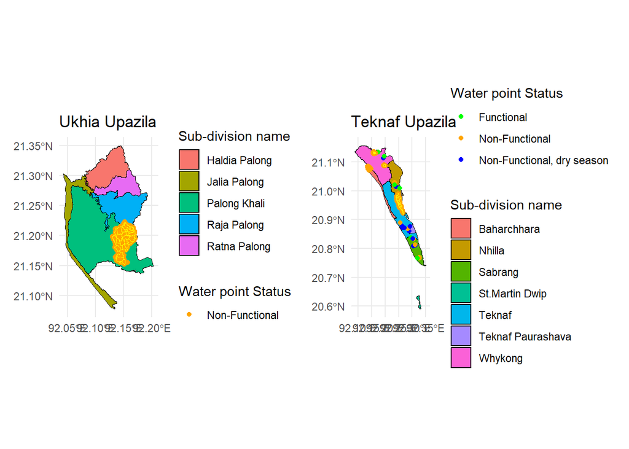

```r
Ukhia <- plot_filtered_district(district_filter = filtered_districts$ADM3_EN == "Ukhia",
                                layer = "ADM4_EN",
                                water_point_filter = filtered_df$clean_adm3 == "Ukhia",
                                camp_outline_filter = camp_outlines$Upazila == "Ukhia",
                                "Ukhia Upazila",
                                "Sub-division name")

Teknarf <- plot_filtered_district(district_filter = filtered_districts$ADM3_EN == "Teknaf",
                                  layer = "ADM4_EN",
                                  water_point_filter = filtered_df$clean_adm3 == "Teknaf",
                                  camp_outline_filter = camp_outlines$Upazila == "Teknaf",
                                  "Teknaf Upazila",
                                  "Sub-division name")

Ukhia + Teknarf
```

Based on the maps above, it is clear that there is still a lot of overlap between water points and refuge camps data. Because of this, it is necessary to disaggregate further, at the sub district level. The sub districts that will be selected for further visualizations are:

In Ukhia: Palong Khali

In Teknaf: Whykong, Nhilla, Teknaf

These were selected because they are the sub-divisions with the largest presence of refugee camps and water points.

## Repeating preivous steps with further geospatial disagregation

The following code chunk contains a function that generates layered maps for water point data, refugee camp boundaries and administrative divisions at the sub-district level. The function is later used to generate plots for Palong Khali sub district located in Ukhia, and Whykong, Teknafm and Nhilla sub districts, located in Teknaf.

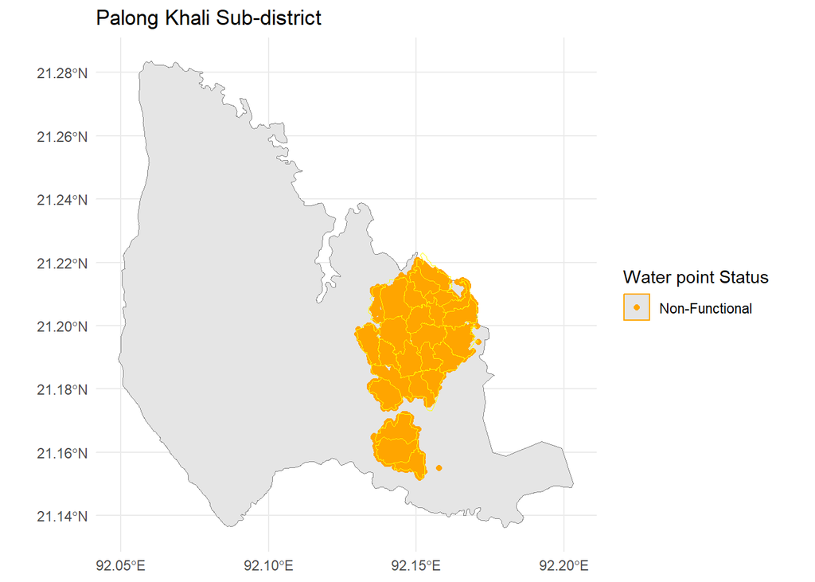

```r
subdistrict_plots <- function(district_name) {

# Filter the sub district data
filtered_subdist <- districts %>%
  filter(ADM4_EN == district_name)

  filtered_subdist_water <- filtered_df %>%
    filter(clean_adm4 == district_name)

  filtered_subdist_camps <- camp_outlines %>%
    filter(Union == district_name)

#Plot the sub district map:
ggplot() +
  geom_sf(data = filtered_subdist, aes(color = ADM4_EN))+
  geom_sf(data = filtered_subdist_water, aes(color = status_clean)) +
  scale_color_manual(values = c("Functional" = "green", "Non-Functional, dry season" = "blue", "Non-Functional" = "orange")) +
  geom_sf(data = filtered_subdist_camps, fill = "transparent", color = "yellow") +
  scale_fill_discrete(name = district_name) +
    labs(
      color = "Water point Status",
      title = paste(district_name, "Sub-district")) +
    theme_minimal()

}

Palong_Khali <- subdistrict_plots("Palong Khali")
Whykong <- subdistrict_plots("Whykong")
Nhilla <- subdistrict_plots("Nhilla")
Teknaf <- subdistrict_plots("Teknaf")

Palong_Khali
```

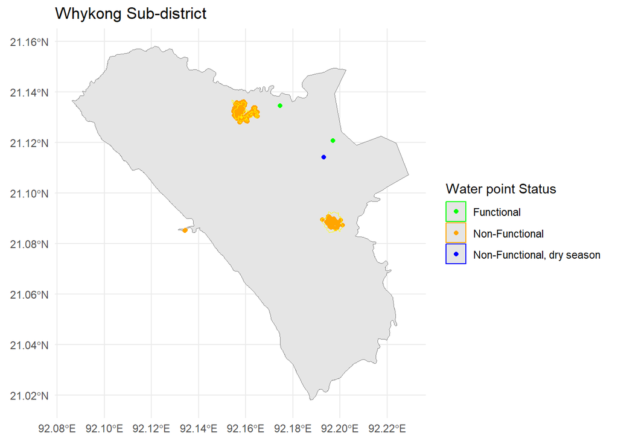

```r
Whykong
```

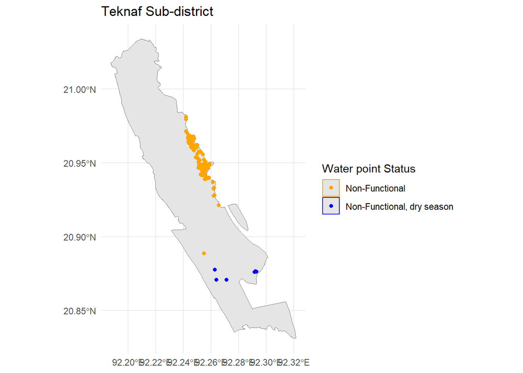

```r
Teknaf
```

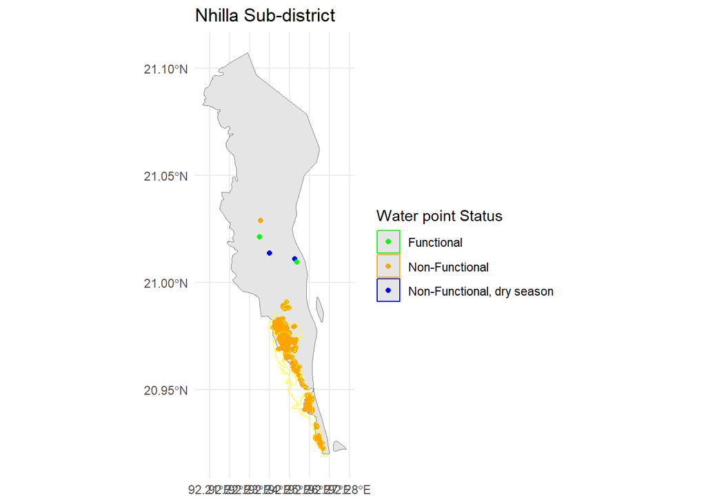

```r
Nhilla
```

## WASH Dataset

The below code take the Tubewell data and renames the long and lat variables because they were called complicated names. It then filters the data by hand-pups and latrines and creates two plots to show where the tubewells are against the camp data and where the ukhia and teknaf are against the camp outlines.

```r
colnames(tubewells)
```

```
 [1] "SL No"                           "Agency"
 [3] "Type of Beneficiaries"           "District"
 [5] "Upazila"                         "Union"
 [7] "AFA"                             "Location/ Camp Name"
 [9] "Block Name"                      "Sub-Block Name"
[11] "Latitude\r\n(Decimal Degrees)"   "Longitude \r\n(Decimal Degrees)"
[13] "Sub Sector"                      "Type of Facilities"
[15] "Sub Type of Facilities"          "# of Tube-wells"
[17] "# of Latrines Cubicles"          "# of Latrines Cubicles Female"
[19] "# of Bathing Cubicles"           "# of Bathing Cubicles Female"
[21] "Depth of \r\nTubewell (Feet)"    "Facilities_Sector_ID"
[23] "Facilities_Agency_ID"            "Comments"
```

```r
# Changing the names of the long and lat colums
tubewells$lat <- tubewells$"Latitude\r\n(Decimal Degrees)"
tubewells$"Latitude\r\n(Decimal Degrees)" <- NULL

tubewells$long <- tubewells$"Longitude \r\n(Decimal Degrees)"
tubewells$"Longitude \r\n(Decimal Degrees)" <- NULL

tubewells_sf <- st_as_sf(tubewells, coords = c("long", "lat"), crs = 4326)

# We only want to see handpumps
tubewell_map <- tubewells_sf %>%
  filter(`Type of Facilities` == "Handpump-Tubewell")

# we only want to see latrines
latrine_map <- tubewells_sf %>%
  filter(`Type of Facilities` == "Latrine")

print(latrine_map)
```

```
Simple feature collection with 35498 features and 22 fields
Geometry type: POINT
Dimension:     XY
Bounding box:  xmin: 92.13001 ymin: 20.93068 xmax: 92.2639 ymax: 21.22278
Geodetic CRS:  WGS 84
# A tibble: 35,498 × 23
   `SL No` Agency `Type of Beneficiaries` District    Upazila Union        AFA
 *   <dbl> <chr>  <chr>                   <chr>       <chr>   <chr>        <chr>
 1       1 NGOF   Rohingya                Cox's Bazar Ukhia   Palong Khali IOM
 2       2 NGOF   Rohingya                Cox's Bazar Ukhia   Palong Khali IOM
 3       3 NGOF   Rohingya                Cox's Bazar Ukhia   Palong Khali IOM
 4       4 NGOF   Rohingya                Cox's Bazar Ukhia   Palong Khali IOM
 5       5 NGOF   Rohingya                Cox's Bazar Ukhia   Palong Khali IOM
 6       6 NGOF   Rohingya                Cox's Bazar Ukhia   Palong Khali IOM
 7       7 NGOF   Rohingya                Cox's Bazar Ukhia   Palong Khali IOM
 8       8 NGOF   Rohingya                Cox's Bazar Ukhia   Palong Khali IOM
 9       9 NGOF   Rohingya                Cox's Bazar Ukhia   Palong Khali IOM
10      10 NGOF   Rohingya                Cox's Bazar Ukhia   Palong Khali IOM
# ℹ 35,488 more rows
# ℹ 16 more variables: `Location/ Camp Name` <chr>, `Block Name` <chr>,
#   `Sub-Block Name` <chr>, `Sub Sector` <chr>, `Type of Facilities` <chr>,
#   `Sub Type of Facilities` <chr>, `# of Tube-wells` <lgl>,
#   `# of Latrines Cubicles` <dbl>, `# of Latrines Cubicles Female` <dbl>,
#   `# of Bathing Cubicles` <lgl>, `# of Bathing Cubicles Female` <lgl>,
#   `Depth of \r\nTubewell (Feet)` <lgl>, Facilities_Sector_ID <chr>, …
```

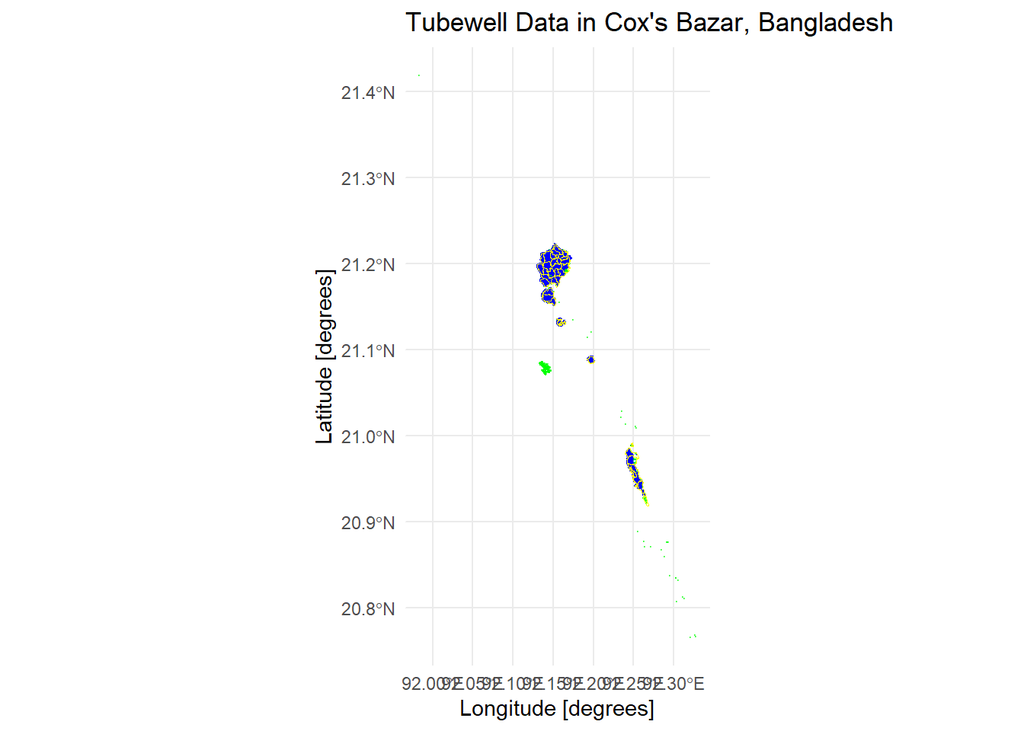

```r
well_graph <- ggplot() +
  geom_sf(data = filtered_df, size=0.05, alpha=0.5, color = "green") +
  geom_sf(data = tubewells_sf, size=0.05, alpha=0.5, color = "blue") +
  geom_sf(data = camp_outlines, fill = "transparent", color = "yellow") +
  theme_minimal() +
  xlab("Longitude [degrees]") +  # Add x-axis label
  ylab("Latitude [degrees]") +  # Add y-axis label
  labs(title = "Tubewell Data in Cox's Bazar, Bangladesh") # Add the title

print(well_graph)
```

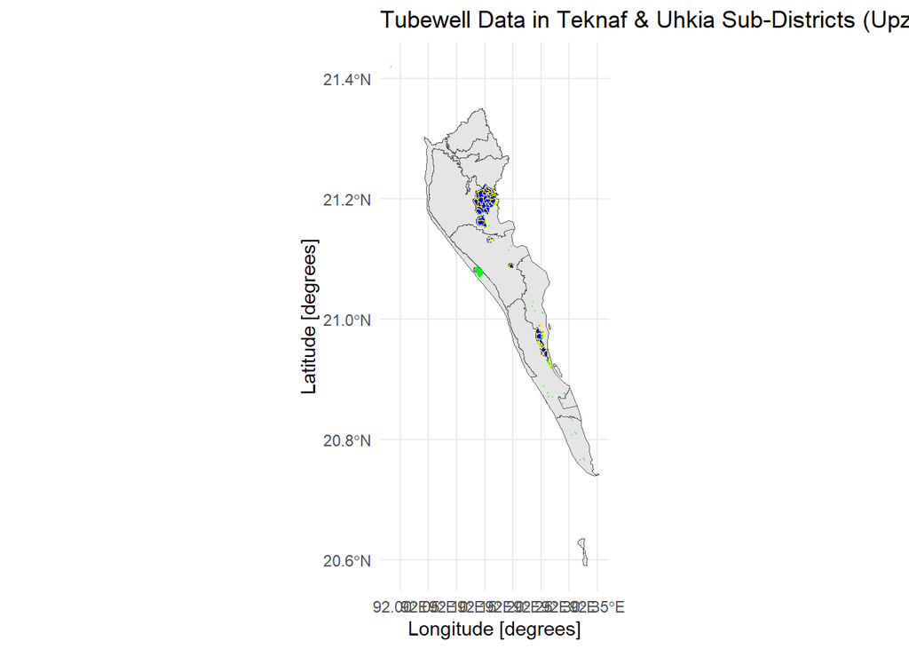

```r
teknaf <- districts %>%
  filter(ADM3_EN == "Teknaf")
ukhia <- districts %>%
  filter(ADM3_EN == "Ukhia")


#Plot all well data in Ukhia
well_graph2 <- ggplot() +
  geom_sf(data = ukhia) +
  geom_sf(data = teknaf) +
  geom_sf(data = filtered_df, size=0.05, alpha=0.5, color = "green") +
  geom_sf(data = tubewells_sf, size=0.05, alpha=0.5, color = "blue") +
  geom_sf(data = camp_outlines, fill = "transparent", color = "yellow") +
  theme_minimal() +
  xlab("Longitude [degrees]") +  # Add x-axis label
  ylab("Latitude [degrees]") +  # Add y-axis label
  labs(title = "Tubewell Data in Teknaf & Uhkia Sub-Districts (Upzilas), Bangladesh") # Add the title

print(well_graph2)
```

## Health Facilities

```r
health_facilities <- health_facilities[complete.cases(health_facilities$Long, health_facilities$Lat), ]

health_sf <- st_as_sf(health_facilities, coords = c("Long", "Lat"), crs = 4326)

# Tubewells per Diarrhea Centers
diarrhea <- health_sf %>%
  filter(Type == "Diarrheal Treatment Center")

print(diarrhea)
```

```
Simple feature collection with 15 features and 8 fields
Geometry type: POINT
Dimension:     XY
Bounding box:  xmin: 92.12847 ymin: 20.87427 xmax: 92.29791 ymax: 21.25398
Geodetic CRS:  WGS 84
# A tibble: 15 × 9
   `Old facility code` `mWater Code` Partner Type  Zone  Functionality `Camp ID`
 * <chr>               <chr>         <chr>   <chr> <chr> <chr>         <chr>
 1 HF_022              22325860      BDRCS/… Diar… <NA>  Functional    <NA>
 2 HF_024              22325884      iccdr,b Diar… <NA>  Planned       <NA>
 3 HF_023              22325877      iccdr,b Diar… <NA>  Planned       <NA>
 4 HF_033              22325970      MSF     Diar… RR (… Functional    Camp 8W
 5 HF_025              22325891      MSF     Diar… RR (… Functional    Camp 8W
 6 HF_027              22325918      MSF     Diar… <NA>  Functional    Camp 16
 7 HF_026              22325901      MSF     Diar… <NA>  Under constr… <NA>
 8 HF_028              22325925      MSF     Diar… <NA>  Planned       <NA>
 9 HF_030              22325949      RHU/GK  Diar… Kutu… Functional    KRC
10 HF_242              22328069      RHU/RT… Diar… <NA>  Functional    Nayapara…
11 <NA>                22032195      RHU/MT… Diar… Naya… Functional    <NA>
12 HF_032              22325963      UNICEF  Diar… <NA>  Planned       Leda A
13 HF_021              22325853      BDRCS   Diar… YY (… Under constr… Camp 19
14 HF_020              22325846      BDRCS   Diar… TT (… Under constr… Camp 12
15 HF_031              22325956      UNICEF  Diar… XX (… Under constr… Camp 18
# ℹ 2 more variables: `Revisit?` <chr>, geometry <POINT [°]>
```

```r
# Using the conversion factor to create the buffer around the camp center point
diarrhea_buffer <- st_buffer(
  diarrhea,
  dist = units::set_units (100, "m")
)

# spatial join the unbuffered shapes to the buffer shapes
   diarrhea_water_joined <- st_join(
     diarrhea_buffer,
     tubewell_map,
     join = st_intersects
)

# Tubewells per Primary Health Center

primary_center <- health_sf %>%
  filter(Type == "Primary Health Center")

print(primary_center)
```

```
Simple feature collection with 48 features and 8 fields
Geometry type: POINT
Dimension:     XY
Bounding box:  xmin: 92.04922 ymin: 20.97099 xmax: 92.2438 ymax: 21.2361
Geodetic CRS:  WGS 84
# A tibble: 48 × 9
   `Old facility code` `mWater Code` Partner Type  Zone  Functionality `Camp ID`
 * <chr>               <chr>         <chr>   <chr> <chr> <chr>         <chr>
 1 HF_218              22327824      BRAC    Prim… JJ (… Functional    Camp 9
 2 HF_217              22327817      BRAC    Prim… KMS … Functional    Camp 2W
 3 HF_216              22327800      BRAC    Prim… Moyn… Functional    Camp 16
 4 <NA>                22032188      BRAC    Prim… II (… Functional    Camp 8E
 5 HF_255              22328193      CZM     Prim… NN (… Functional    Camp 11
 6 HF_254              22328186      Coast … Prim… BMS … Functional    Camp 9
 7 HF_119              22326830      GK/OBA… Prim… UU (… Functional    Camp 4
 8 HF_219              22327831      GK/RTMI Prim… OO (… Functional    Camp 4
 9 HF_220              22327848      Global… Prim… Moyn… Functional    Camp 16
10 HF_223              22327879      IOM     Prim… BMS … Functional    Camp 9
# ℹ 38 more rows
# ℹ 2 more variables: `Revisit?` <chr>, geometry <POINT [°]>
```

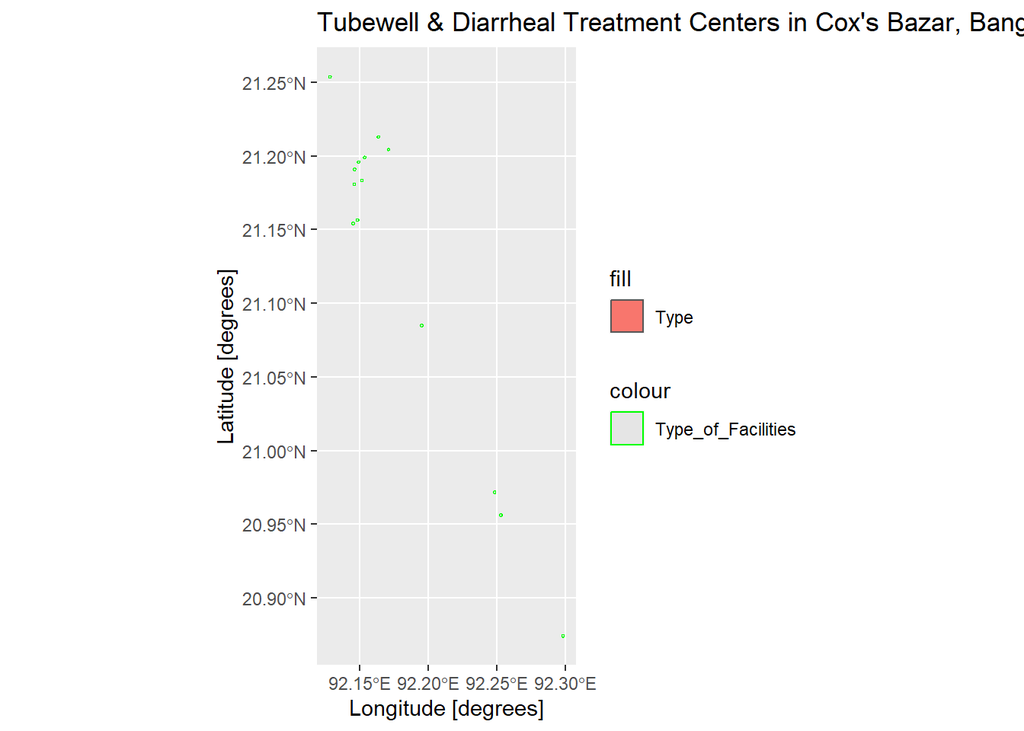

```r
# Using the conversion factor to create the buffer around the camp center point
primary_buffer <- st_buffer(
  primary_center,
  dist = units::set_units (100, "m")
)

# spatial join the unbuffered shapes to the buffer shapes
   primary_water_joined <- st_join(
     primary_buffer,
     tubewell_map,
     join = st_intersects
)


# Tubewells per Labour Room or SRH only

labor_room <- health_sf %>%
  filter(Type == "Labour Room or SRH only")

# Using the conversion factor to create the buffer around the camp center point
labor_buffer <- st_buffer(
  labor_room,
  dist = units::set_units (100, "m")
)

# spatial join the unbuffered shapes to the buffer shapes
labor_water_joined <- st_join(
     labor_buffer,
     tubewell_map,
     join = st_intersects
)


# Tubewells per Health Posts (fixed)

health_post <- health_sf %>%
  filter(Type == "Health Post (fixed)")

# Using the conversion factor to create the buffer around the camp center point
post_buffer <- st_buffer(
  health_post,
  dist = units::set_units (100, "m")
)

# spatial join the unbuffered shapes to the buffer shapes
post_water_joined <- st_join(
     post_buffer,
     tubewell_map,
     join = st_intersects
)

# Tubewell & Diarrheal Treatment Centers in Cox's Bazar, Bangladesh

ggplot() +
  geom_sf(data = diarrhea_water_joined, aes(fill = 'Type')) +
  geom_sf(data = diarrhea_water_joined, aes(color = 'Type_of_Facilities')) +
  scale_color_manual(values = c("green", "blue")) +  # Set specific colors
  xlab("Longitude [degrees]") +
  ylab("Latitude [degrees]") +
  labs(title = "Tubewell & Diarrheal Treatment Centers in Cox's Bazar, Bangladesh")
```

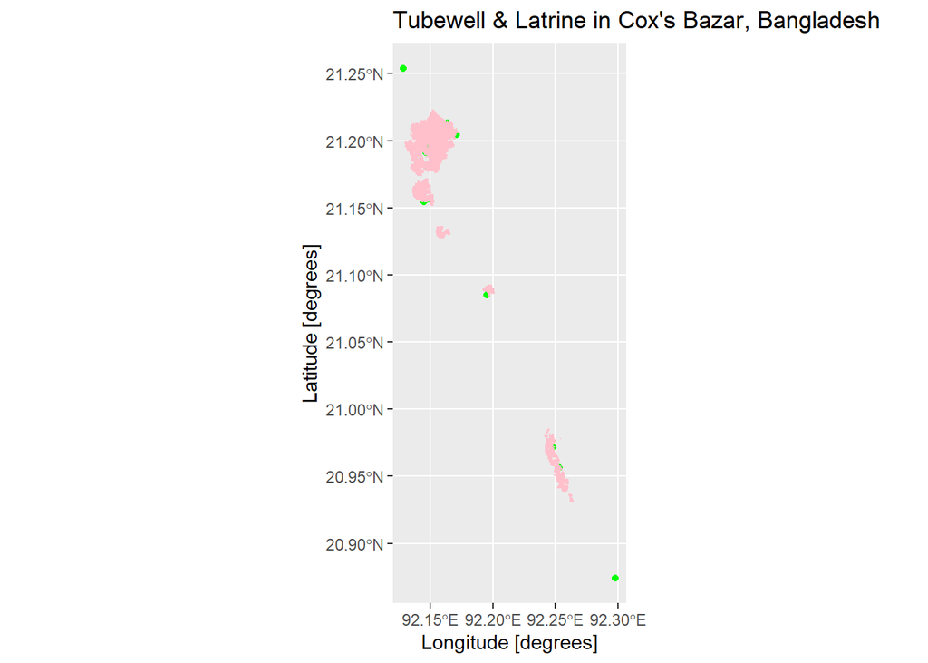

```r
# Latrine & Diarrheal Treatment Centers in Cox's Bazar, Bangladesh

ggplot() +
  geom_sf(data = diarrhea, color = "green") +
  geom_sf(data = latrine_map, color = "pink", size=0.05, alpha=0.5) +
  xlab("Longitude [degrees]") +
  ylab("Latitude [degrees]") +
  labs(title = "Tubewell & Latrine in Cox's Bazar, Bangladesh")
```

## 2D Kernel Density Estimation

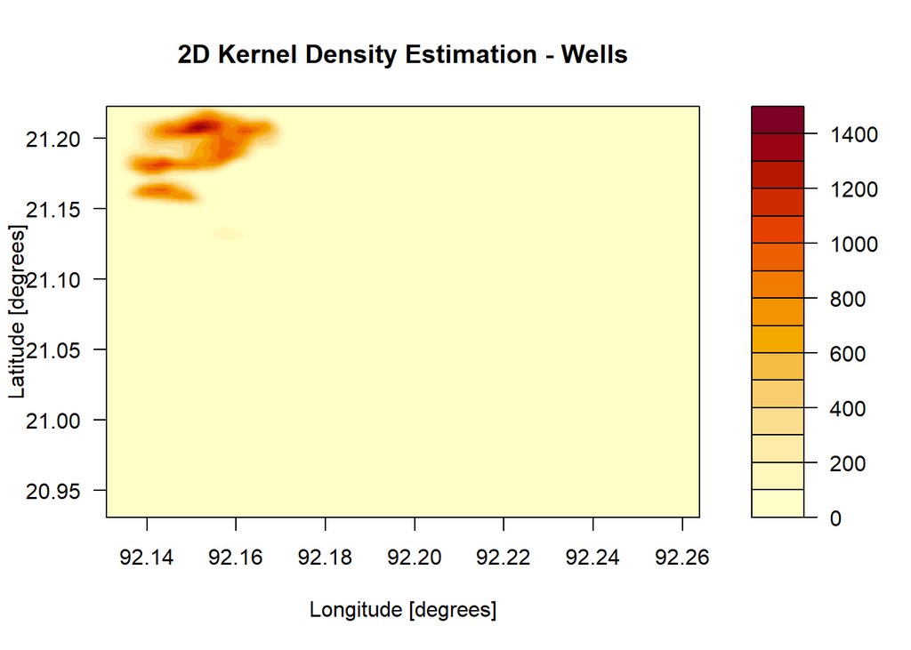

```r
wells <- tubewells_sf %>%
  filter(`Type of Facilities` == "Handpump-Tubewell")
latrines <- tubewells_sf %>%
  filter(`Type of Facilities` == "Latrine")

# Function to extract coordinates from the 'geometry' column of an sf object
extract_coordinates <- function(sf_object) {
  coords <- st_coordinates(sf_object)
  data.frame(x = coords[, 1], y = coords[, 2])
}

# Extract coordinates from 'wells' and 'latrines'
wells_coords <- extract_coordinates(wells)
latrines_coords <- extract_coordinates(latrines)

# Perform kernel density estimation for wells
density_wells <- kde2d(wells_coords$x, wells_coords$y, n = 100)

# Perform kernel density estimation for latrines
density_latrines <- kde2d(latrines_coords$x, latrines_coords$y, n = 100)

# Plot the kernel density estimates
filled.contour(density_wells, main = "2D Kernel Density Estimation - Wells", xlab = "Longitude [degrees]", ylab = "Latitude [degrees]")
```

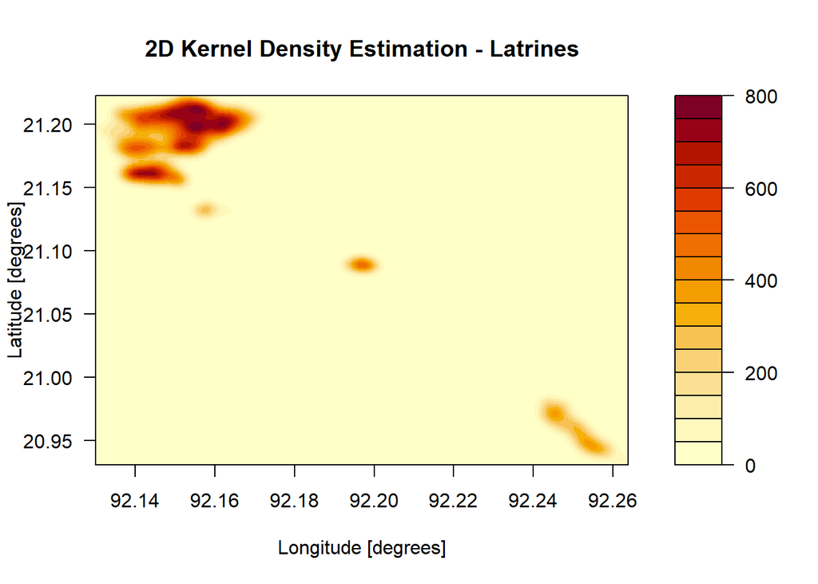

```r
filled.contour(density_latrines, main = "2D Kernel Density Estimation - Latrines", xlab = "Longitude [degrees]", ylab = "Latitude [degrees]")
```

# High-Level Discussion of Results

We see that, according to the WPDX data, most of the wells in the dataset are non-functional, while only a few are functional. Given the high proportion of the former, it seems possible that there is a data-entry issue. If not, however, it is alarming that so many wells are non-functional, and so funding for maintenance and training/capacity building should be policy priorities moving forward.In terms of the camps, our figures show that most of the refugee camps are concentrated in Teknaf and Ukhia subdistricts (also called upazilas).

Overall, our project requires greater harmonization between different well datasets, such as merging the 2 well datasets employed. In addition, spatial clustering could have been employed, for instance to assign camps to wells, weighted by camp-level population density. We were also unable to find such, but spatial health data, e.g. showing geographic variation in prevalance of water-borne diseases, such as cholera, diarrhea, etc. would have been useful, would have allowed us to expand from mapping WASH access to exploration of the WASH-health causal pathways.